# High basal expression can trigger self-activation of transceiver clones

### Set up environment

```python
import lateral_signaling as lsig
import numpy as np
import pandas as pd
from tqdm import tqdm
import numba

import scipy.integrate as sint
from scipy.spatial import Voronoi

import holoviews as hv
import colorcet as cc
hv.extension("matplotlib")
```

```python
%load_ext blackcellmagic
```

## Promoter leakiness

In Model 2a (copied below) we use the parameter $\lambda$ to denote the production rate of $S$ due to leakiness.

\begin{align} \frac{\mathrm{d}\, \vec{s}}{\mathrm{d} t} &= \lambda + \alpha \frac{\left(\vec{\overline{s}}_{(t-\tau)}\right)^p}{k^p + \left(\delta \vec{s}_{(t-\tau)}\right)^p + \left(\vec{\overline{s}}_{(t-\tau)}\right)^p} - \vec{s} \\[1em] \vec{\overline{s}} &= \frac{1}{P_0} L \vec{s} = \frac{\ell}{P_0} A \vec{s} \end{align}

#### Define function(s) for DDE integration

```python
def tc_rhs_2a_nosender(S, S_delay, Adj, alpha, k, p, delta, lambda_, ell):
    """
    Right-hand side of the transciever circuit delay
    differential equation.
    """

    # Set perimeter at density = 1
    P0 = 6 / np.sqrt(3)

    # Get input signal across each interface
    S_bar = 6 * ell * Adj @ S_delay / P0

    # Calculate dS/dt
    dS_dt = (
        lambda_
        + alpha
        * (S_bar ** p)
        / (k ** p + (delta * S_delay) ** p + S_bar ** p)
        - S
    )

    return dS_dt


def get_rhs(Adj, func):
    """Given the indices of sender cells, returns a
    function `rhs` with call signature
    rhs(S, S_delay, *args) that can be passed to
    `lsig.integrate_DDE` and.or `lsig.integrate_DDE_varargs`.
    """

    def rhs(S, S_delay, *args):
        return func(S, S_delay, Adj, *args)

    return rhs
```

```python
# Make square lattice
rows = cols = 10
r = 1.   # cell-cell distance
X, Adj = lsig.hex_Adj(rows, cols, r=r, sparse=True)

# Get # cells
n = X.shape[0]
```

#### *In silico* identification of self-activating clones

We hypothesized that transfection clones primarily differ in their promoter strength and basal activity (leakiness), due to random insertion in the genome. We will scan through various values of $\alpha$ (maximum strength of the inducible promoter) and $\lambda$ (basal promoter activity), looking for clones that activate fluorescence in the absence of a sender cell.

First we acquire the right-hand-side of the dynamical equation

```python
# Get RHS
rhs = get_rhs(Adj, tc_rhs_2a_nosender)
```

We set the time-window long enough to reach stationarity.

```python
# Set time parameters
tmax = 5
nt_t = 100
nt = int(nt_t * tmax) + 1
t = np.linspace(0, tmax, nt)
```

Now we sample

```python
# Set options for parameter sampling
lmin, lmax = -6, -2    # lambda ~ [10**lmin, 10**lmax]
amin, amax = 0, 6   # alpha ~ [amin, amax]
n_lambda = 25
n_alpha = 25

# Sampling parameters
n_reps = 5

# Sample free parameters
lambda_space = np.logspace(lmin, lmax, n_lambda)
alpha_space = np.logspace(-1, 1, n_alpha)
rep_space = np.arange(n_reps)
free_params = (rep_space, lambda_space, alpha_space)

# Get all pairwise combinations of free parameters
param_space = np.meshgrid(*free_params)
param_space = np.array(param_space, dtype=np.float32).T.reshape(-1, len(free_params))

# Get indices for pairwise combinations
param_idx = np.meshgrid(*[np.arange(p.size) for p in free_params])
param_idx = np.array(param_idx, dtype=int).T.reshape(-1, len(free_params))

n_runs = param_space.shape[0]
```

For the remaining parameters, we use our example parameter set

```python
# Set signaling parameters
k = 0.12
p = 2
delta = 3

# Get cell-cell contact length
ell = r / np.sqrt(3)

# Set delay
delay = 0.4
```

We initialize transceivers at fluorescence values of $0$ and integrate the DDEs, keeping only the final fluorescence values.

To simulate the cell-cell variation in a normal population, we will perturb the initial state very slightly from zero by drawing initial fluorescence from a half-Normal distribution centered at $\mu=0$ with mean $\langle S \rangle = \lambda$. Using the [Distribution Explorer](https://distribution-explorer.github.io/continuous/halfnormal.html),

\begin{align} \langle S \rangle &= \lambda \\[1em] \mu + \sqrt{\frac{2 \sigma^2}{\pi}} &= \lambda \\[1em] \sigma &= \sqrt{\frac{\pi}{2}} \lambda \end{align}

```python
from scipy.stats import halfnorm

# Set seed
np.random.seed(2020)

# Minimally perturb initial fluorescence
rv_shape = n_lambda, n_reps, n
init_arr = halfnorm.rvs(0, np.sqrt(np.pi/2) * lambda_space[:, np.newaxis, np.newaxis], rv_shape)
init_arr = np.transpose(init_arr, (1, 0, 2))
```

First I need to make sure that there's no self-activation just from the random initial conditions

```python
# Initialize results vector
S_fin = np.empty((n_reps, n_lambda, n_alpha, n), dtype=np.float32)

iterator = range(n_runs)
iterator = tqdm(iterator)
for i in iterator:

    # Get parameters
    rep, lambda_i, alpha_i = param_idx[i]
    lambda_, alpha = lambda_space[lambda_i], alpha_space[alpha_i]

    # Package parameters
    args = (alpha, k, p, delta, lambda_, ell)

    # Get initial conditions
    S0 = init_arr[rep, lambda_i]

    # Simulate
    S_t = lsig.integrate_DDE(
        t,
        rhs,
        dde_args=args,
        E0=S0,
        delay=delay,
        min_delay=5,
    )

#     # Get indices for re-packaging
#     lambda_i = i % n_lambda
#     alpha_i = i // (n_reps * n_lambda)

    S_fin[rep, lambda_i, alpha_i] = S_t[-1]
```

Now we decide whether each cell is activated by comparing it to the activation threshold $k$. For each run, we calculate the proportion of cells activated `S_act_prop`.

```python
# Calculate % of cells activated at final time-point
S_activated = S_fin > k
S_act_prop = S_activated.mean(axis=(0, 3))
```

Now we represent the proportion activated as a percentage and create a phase plot to observe how self-activation is influenced by $\alpha$ and $\lambda$

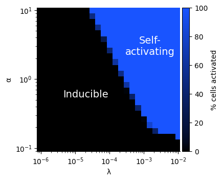

```python
%%capture --no-display

data={
    "lambda": lambda_space,
    "alpha": alpha_space,
    "% cells activated": S_act_prop.T * 100
}

p1 = hv.QuadMesh(
    data=data,
    kdims=["lambda", "alpha"],
    vdims=["% cells activated"]
).opts(
    logx=True,
    logy=True,
#     color = "% activation",
    cmap="kb",
#     aspect=2.2,
    xlabel="λ",
    ylabel="α",
#     title="Genome insertion site can influence \nself-activation of transceiver clones",
    colorbar=True,
)

t1 = hv.Text(2e-5, 6e-1, 'Inducible', fontsize=14).opts(color="white")
t2 = hv.Text(1.5e-3, 3e0, 'Self-\nactivating', fontsize=14).opts(color="white")

hv.output(p1 * t1 * t2, dpi=100)
```

To demonstrate this, we select parameter sets from each region and plot frames from their simulations.

**Inducible clone**

```python
# Get parameters
lambda_i1, alpha_i1 = 6, 14
lambda_1, alpha1 = lambda_space[lambda_i1], alpha_space[alpha_i1]

# Package parameters
args1 = (alpha1, k, p, delta, lambda_1, ell)

# Get initial conditions
rep = 0
S01 = init_arr[rep, lambda_i1]

# Simulate
S_t1 = lsig.integrate_DDE(
    t,
    rhs,
    dde_args=args1,
    E0=S01,
    delay=delay,
    min_delay=5,
)
```

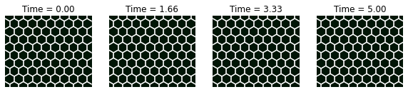

```python
import matplotlib.pyplot as plt
%matplotlib inline

# Set dimensions for a grid of frames
nrows, ncols = 1, 4

# Render frames
nplot = nrows * ncols
idx = [int(i) for i in np.linspace(0, nt-1, nplot)]
fig1, axs1 = plt.subplots(nrows=nrows, ncols=ncols, figsize=(10,6))
for ax, i in zip(axs1.flat, idx):
    title=f"Time = {t[i]:.2f}"
    lsig.inspect_out(
        ax1=ax,
        X=X,
        cell_radii=np.ones(n) * ell,
        var=S_t1,
        idx=i,
        vmin=0,
        vmax=1,
        cmap="kgy",
#         xlim=xlim,
#         ylim=ylim,
        title=title,
        ifcc="w",
    )
```

**Self-activating clone**

```python
# Get parameters
lambda_i2, alpha_i2 = 18, 15
lambda_2, alpha2 = lambda_space[lambda_i2], alpha_space[alpha_i2]

# Package parameters
args2 = (alpha2, k, p, delta, lambda_2, ell)

# Get initial conditions
rep = 0
S02 = init_arr[rep, lambda_i2]

# Simulate
S_t2 = lsig.integrate_DDE(
    t,
    rhs,
    dde_args=args2,
    E0=S02,
    delay=delay,
    min_delay=5,
)
```

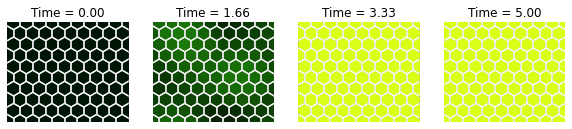

```python
import matplotlib.pyplot as plt
%matplotlib inline

# Set dimensions for a grid of frames
nrows, ncols = 1, 4

# Render frames
nplot = nrows * ncols
idx = [int(i) for i in np.linspace(0, nt-1, nplot)]
fig2, axs2 = plt.subplots(nrows=nrows, ncols=ncols, figsize=(10,6))
for ax, i in zip(axs2.flat, idx):
    title=f"Time = {t[i]:.2f}"
    lsig.inspect_out(
        ax1=ax,
        X=X,
        cell_radii=np.ones(n) * ell,
        var=S_t2,
        idx=i,
        vmin=0,
        vmax=1,
        cmap="kgy",
#         xlim=xlim,
#         ylim=ylim,
        title=title,
        ifcc="w",
    )
```

```python
import os
```

## Save phase plots

```python
# Set filepath and format
fmt = "png"
dirname = "plots"
fname = f"self_activation_plot_lambda_{10**lmin:.2e}-{10**lmax:.2e}_alpha_{amin:.2f}-{amax:.2f}" + "." + fmt

fpath = os.path.join(dirname, fname)
```

```python
%%capture --no-display

hv.save(p1, fpath, fmt=fmt, dpi=150)
```

```python
# Set filepath and format
fmt = "png"
dirname = "plots"
fname = f"self_activation_plot_labeled_lambda_{10**lmin:.2e}-{10**lmax:.2e}_alpha_{amin:.2f}-{amax:.2f}" + "." + fmt

fpath = os.path.join(dirname, fname)
```

```python
%%capture --no-display

hv.save(p1 * t1 * t2, fpath, fmt=fmt, dpi=150)
```

## Save examples of clones

```python
fmt = "png"
dirname = "plots"
fname1 = f"inducible_clone_lambda_{lambda_1:.2e}_alpha_{alpha1:.2f}" + "." + fmt
fpath1 = os.path.join(dirname, fname1)
```

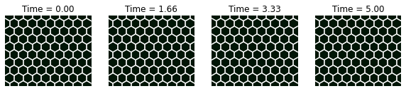

```python
import matplotlib.pyplot as plt
%matplotlib inline

# Set dimensions for a grid of frames
nrows, ncols = 1, 4

# Render frames
nplot = nrows * ncols
idx = [int(i) for i in np.linspace(0, nt-1, nplot)]
fig1, axs1 = plt.subplots(nrows=nrows, ncols=ncols, figsize=(10,6))
for ax, i in zip(axs1.flat, idx):
    title=f"Time = {t[i]:.2f}"
    lsig.inspect_out(
        ax1=ax,
        X=X,
        cell_radii=np.ones(n) * ell,
        var=S_t1,
        idx=i,
        vmin=0,
        vmax=1,
        cmap="kgy",
#         xlim=xlim,
#         ylim=ylim,
        title=title,
        ifcc="w",
    )

plt.savefig(fpath1, dpi=150, format=fmt)
```

```python
fmt = "png"
dirname = "plots"
fname2 = f"self_activating_clone_lambda_{lambda_2:.2e}_alpha_{alpha2:.2f}" + "." + fmt
fpath2 = os.path.join(dirname, fname2)
```

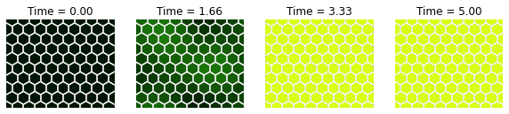

```python
import matplotlib.pyplot as plt
%matplotlib inline

# Set dimensions for a grid of frames
nrows, ncols = 1, 4

# Render frames
nplot = nrows * ncols
idx = [int(i) for i in np.linspace(0, nt-1, nplot)]
fig2, axs2 = plt.subplots(nrows=nrows, ncols=ncols, figsize=(10,6))
for ax, i in zip(axs2.flat, idx):
    title=f"Time = {t[i]:.2f}"
    lsig.inspect_out(
        ax1=ax,
        X=X,
        cell_radii=np.ones(n) * ell,
        var=S_t2,
        idx=i,
        vmin=0,
        vmax=1,
        cmap="kgy",
#         xlim=xlim,
#         ylim=ylim,
        title=title,
        ifcc="w",
    )

plt.savefig(fpath2, dpi=150, format=fmt)
```

```python
%load_ext watermark
```

```
The watermark extension is already loaded. To reload it, use:
  %reload_ext watermark
```

```python
%watermark -v -p numpy,scipy,numba,holoviews,jupyterlab
```

```
CPython 3.7.7
IPython 7.18.1

numpy 1.18.1
scipy 1.4.1
numba 0.51.2
holoviews 1.13.2
jupyterlab 1.2.6
```